# Data Analysis

## No Ciliated Edge Pixels

Three comparisons pairwise comparisons  
host vs. mox host vs. sox sox vs. mox

## PLS

```r
table(msidata.nociliatededge$Class)
```

```
 Green    Red Tissue
   788   3022  14914
```

```r
ddd<-data.frame(pData(msidata.nociliatededge))
ddd$xy<-paste(ddd$x, ddd$y,sep='-')
subset<-data.frame((pData(msidata.nociliatededge) %>% group_by(Class) %>% sample_n(size=700,replace = F)))
subset$xy<-paste(subset$x, subset$y,sep='-')
dnew<-ddd[ddd$xy %in% subset$xy,]
coordsSubset<-rownames(dnew)
nce.subset<-msidata.nociliatededge[,rownames(pData(msidata.nociliatededge)) %in% coordsSubset]
nce.subset
```

[output not shown]

```r
table(nce.subset$Class)
```

```
 Green    Red Tissue
   700    700    700
```

```r
## Assign numbers for CV groups
pixelNo<-nrow(pData(nce.subset))
randNum<-sample(1:10,size = pixelNo,replace = T) ## For now, just split the data 10 ways, increase to see how changes in overnight run
pData(nce.subset)$cvgroup<-as.vector(randNum)
```

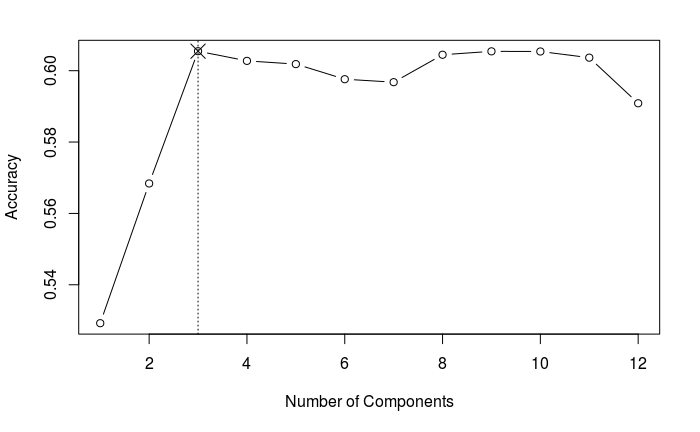

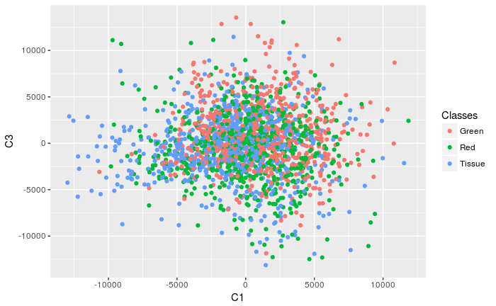

### OPLS

#### Host vs. mox

```r
hostmox<-msidata.nociliatededge[,msidata.nociliatededge$Class %in% c('Red','Tissue')]
table(hostmox$Class)
```

```
   Red Tissue
  3022  14914
```

```r
ddd<-data.frame(pData(hostmox))
ddd$xy<-paste(ddd$x, ddd$y,sep='-')
subset<-data.frame((pData(hostmox) %>% group_by(Class) %>% sample_n(size=700,replace = F)))
subset$xy<-paste(subset$x, subset$y,sep='-')
dnew<-ddd[ddd$xy %in% subset$xy,]
coordsSubset<-rownames(dnew)
hostmox.subset<-hostmox[,rownames(pData(hostmox)) %in% coordsSubset]
hostmox.subset
```

[output not shown]

```r
table(hostmox.subset$Class)
```

```
   Red Tissue
   700    700
```

```r
## Assign numbers for CV groups
pixelNo<-nrow(pData(hostmox.subset))
randNum<-sample(1:10,size = pixelNo,replace = T) ## For now, just split the data 10 ways, increase to see how changes in overnight run
pData(hostmox.subset)$cvgroup<-as.vector(randNum)
```

Preform opls cross validation to select best model representation

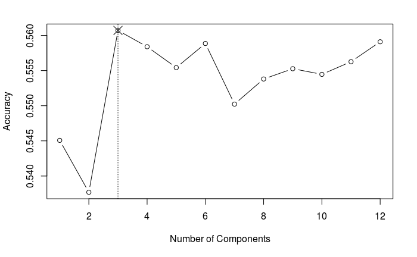

Re-run opls on all the data & visualize

```r
comp<-3
hostmox.opls<-OPLS(x=hostmox.subset,y=as.factor(hostmox.subset$Class), ncomp=comp)
```

```
OPLS: Centering data.
OPLS: Fitting orthogonal partial least squares components.
OPLS: Predicting for ncomp = 3.
OPLS: Done.
```

```r
summary(hostmox.opls)
```

```
$`ncomp = 3`
                  Red    Tissue
Accuracy    0.6121429 0.6121429
Sensitivity 0.6142857 0.6100000
Specificity 0.6100000 0.6142857
FDR         0.3883357 0.3873745
```

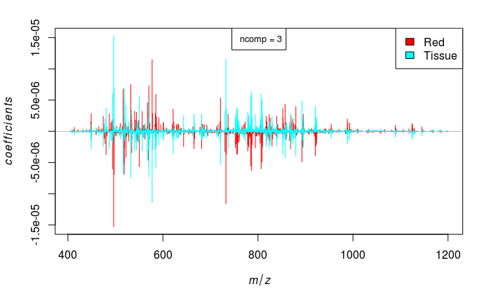

```r
plot(hostmox.opls)
```

```r
topLabels(hostmox.opls, n=50)
```

|  | mz | ncomp | column | coefficients | loadings | Oloadings | weights | Oweights |
| --- | --- | --- | --- | --- | --- | --- | --- | --- |
| 1 | 496.3401 | 3 | Tissue | 1.527429e-05 | -0.498883137 | -1.790509e-02 | -0.35606058 | 0.0041824570 |
| 2 | 732.5543 | 3 | Tissue | 1.162517e-05 | -0.230599155 | -2.705495e-01 | -0.27099565 | -0.0990534482 |
| 3 | 577.2627 | 3 | Red | 1.147266e-05 | 0.556821300 | 1.694928e-01 | 0.26744054 | -0.1709779511 |
| 4 | 532.2799 | 3 | Red | 7.464674e-06 | 0.334915791 | 2.462942e-01 | 0.17400984 | 0.1095564421 |
| 5 | 570.3541 | 3 | Red | 7.283544e-06 | 0.192192201 | -6.705376e-02 | 0.16978750 | 0.0015615024 |
| 6 | 497.3437 | 3 | Tissue | 6.946318e-06 | -0.163036425 | 1.699324e-02 | -0.16192638 | 0.0197038143 |
| 7 | 518.4945 | 3 | Tissue | 6.912631e-06 | -0.253009999 | 9.451627e-03 | -0.16114110 | 0.0939272911 |
| 8 | 516.3069 | 3 | Red | 6.753348e-06 | 0.411720331 | 2.594732e-01 | 0.15742804 | 0.1969394484 |
| 9 | 786.6012 | 3 | Tissue | 6.315912e-06 | -0.160840200 | -1.569511e-01 | -0.14723092 | -0.0875138212 |
| 10 | 494.3251 | 3 | Tissue | 6.009687e-06 | -0.277065921 | 7.151949e-01 | -0.14009248 | 0.5093043989 |

[output cut: 40 more lines]

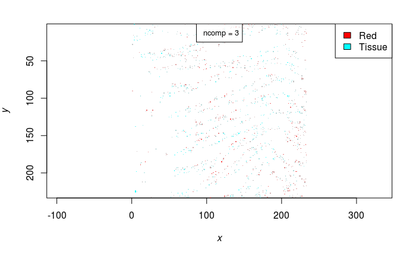

```r
image(hostmox.opls, model=list(ncomp=comp))
```

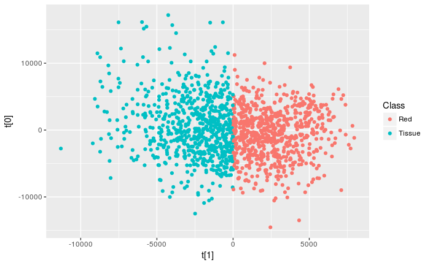

```r
scores<-hostmox.opls@resultData$`ncomp = 3`
opls.scores<-data.frame(t0=scores$Oscores, t1=scores$scores, Class=scores$classes)
ggplot(opls.scores, aes(x=C1, y=t0.C3, color=Class)) + geom_point() + xlab('t[1]') + ylab('t[0]')
```

Still not a significant modeling attempt (fdr > 0.05)

#### Host vs. sox

```r
hostsox<-msidata.nociliatededge[,msidata.nociliatededge$Class %in% c('Green','Tissue')]
table(hostsox$Class)
```

```
 Green Tissue
   788  14914
```

```r
ddd<-data.frame(pData(hostsox))
ddd$xy<-paste(ddd$x, ddd$y,sep='-')
subset<-data.frame((pData(hostsox) %>% group_by(Class) %>% sample_n(size=700,replace = F)))
subset$xy<-paste(subset$x, subset$y,sep='-')
dnew<-ddd[ddd$xy %in% subset$xy,]
coordsSubset<-rownames(dnew)
hostsox.subset<-hostsox[,rownames(pData(hostsox)) %in% coordsSubset]
hostsox.subset
```

[output not shown]

```r
table(hostsox.subset$Class)
```

```
 Green Tissue
   700    700
```

```r
## Assign numbers for CV groups
pixelNo<-nrow(pData(hostsox.subset))
randNum<-sample(1:10,size = pixelNo,replace = T) ## For now, just split the data 10 ways, increase to see how changes in overnight run
pData(hostsox.subset)$cvgroup<-as.vector(randNum)
```

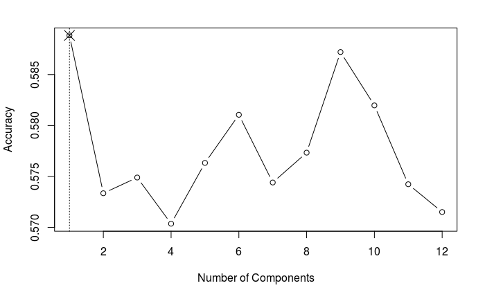

```r
comp<-1
hostsox.opls<-OPLS(x=hostsox.subset,y=as.factor(hostsox.subset$Class), ncomp=comp)
```

```
OPLS: Centering data.
OPLS: Fitting orthogonal partial least squares components.
OPLS: Predicting for ncomp = 1.
OPLS: Done.
```

```r
summary(hostsox.opls)
```

```
$`ncomp = 1`
                Green    Tissue
Accuracy    0.6292857 0.6292857
Sensitivity 0.6428571 0.6157143
Specificity 0.6157143 0.6428571
FDR         0.3741307 0.3671072
```

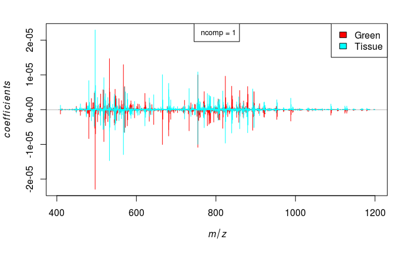

```r
plot(hostsox.opls)
```

```r
topLabels(hostsox.opls, n=50)
```

|  | mz | ncomp | column | coefficients | loadings | Oloadings | weights | Oweights |
| --- | --- | --- | --- | --- | --- | --- | --- | --- |
| 1 | 496.3401 | 1 | Tissue | 2.292731e-05 | -0.691083620 | -0.242333571 | -0.39889005 | -0.314853830 |
| 2 | 532.2799 | 1 | Green | 1.468033e-05 | 0.215680910 | 0.296241838 | 0.25540884 | 0.149821839 |
| 3 | 567.4141 | 1 | Green | 1.294057e-05 | 0.145029040 | 0.148528733 | 0.22514050 | -0.018878649 |
| 4 | 754.5378 | 1 | Tissue | 1.084600e-05 | -0.353500971 | -0.031166940 | -0.18869907 | -0.088070438 |
| 5 | 665.4992 | 1 | Tissue | 1.004404e-05 | -0.121719368 | 0.008929003 | -0.17474655 | 0.131082914 |
| 6 | 754.5348 | 1 | Green | 9.991931e-06 | 0.169409094 | 0.333128558 | 0.17383993 | 0.252693886 |
| 7 | 823.6794 | 1 | Green | 9.629763e-06 | 0.158803687 | 0.074042944 | 0.16753893 | -0.007272696 |
| 8 | 518.3224 | 1 | Tissue | 9.205999e-06 | -0.544966579 | 0.279739902 | -0.16016626 | 0.023197519 |
| 9 | 480.3454 | 1 | Tissue | 8.351136e-06 | -0.102414299 | -0.054087408 | -0.14529334 | 0.046448434 |
| 10 | 681.0893 | 1 | Tissue | 7.579961e-06 | 0.047572020 | -0.380881611 | -0.13187641 | -0.170143799 |

[output cut: 40 more lines]

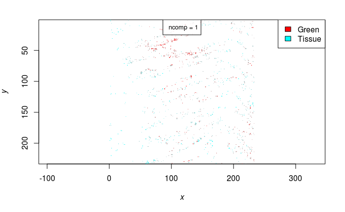

```r
image(hostsox.opls, model=list(ncomp=comp))
```

```r
scores<-hostsox.opls@resultData$`ncomp = 1`
opls.scores<-data.frame(t0=scores$Oscores, t1=scores$scores, Class=scores$classes)
ggplot(opls.scores, aes(x=C1, y=t0.C1, color=Class)) + geom_point() + xlab('t[1]') + ylab('t[0]')
```

```
Error in eval(expr, envir, enclos) : object 't0.C1' not found
```

Not a predtive model with OPLS (no t-orthoganal scores calculated )

#### sox vs. mox

```r
moxsox<-msidata.nociliatededge[,msidata.nociliatededge$Class %in% c('Green','Red')]
table(moxsox$Class)
```

```
Green   Red
  788  3022
```

```r
ddd<-data.frame(pData(moxsox))
ddd$xy<-paste(ddd$x, ddd$y,sep='-')
subset<-data.frame((pData(moxsox) %>% group_by(Class) %>% sample_n(size=700,replace = F)))
subset$xy<-paste(subset$x, subset$y,sep='-')
dnew<-ddd[ddd$xy %in% subset$xy,]
coordsSubset<-rownames(dnew)
moxsox.subset<-moxsox[,rownames(pData(moxsox)) %in% coordsSubset]
moxsox.subset
```

[output not shown]

```r
table(moxsox.subset$Class)
```

```
Green   Red
  700   700
```

```r
## Assign numbers for CV groups
pixelNo<-nrow(pData(moxsox.subset))
randNum<-sample(1:10,size = pixelNo,replace = T) ## For now, just split the data 10 ways, increase to see how changes in overnight run
pData(moxsox.subset)$cvgroup<-as.vector(randNum)
```

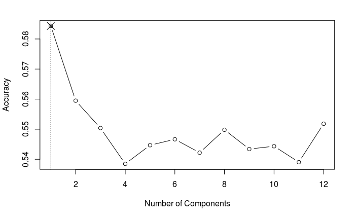

```r
comp<-1
moxsox.opls<-OPLS(x=moxsox.subset,y=as.factor(moxsox.subset$Class), ncomp=comp)
```

```
OPLS: Centering data.
OPLS: Fitting orthogonal partial least squares components.
OPLS: Predicting for ncomp = 1.
OPLS: Done.
```

```r
summary(moxsox.opls)
```

```
$`ncomp = 1`
                Green       Red
Accuracy    0.6314286 0.6314286
Sensitivity 0.6185714 0.6442857
Specificity 0.6442857 0.6185714
FDR         0.3651026 0.3718663
```

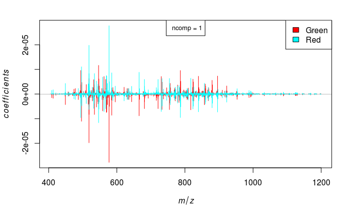

```r
plot(moxsox.opls)
```

```r
topLabels(moxsox.opls, n=50)
```

|  | mz | ncomp | column | coefficients | loadings | Oloadings | weights | Oweights |
| --- | --- | --- | --- | --- | --- | --- | --- | --- |
| 1 | 577.2627 | 1 | Red | 2.774122e-05 | -0.516665492 | -0.643210751 | -0.45103876 | -0.49081599 |
| 2 | 518.3224 | 1 | Red | 1.978992e-05 | -0.307620957 | -0.484174113 | -0.32176017 | -0.33504143 |
| 3 | 546.4886 | 1 | Green | 1.163767e-05 | 0.232634067 | 0.096016357 | 0.18921450 | 0.04262075 |
| 4 | 496.3401 | 1 | Red | 1.105499e-05 | -0.049359852 | -0.284177259 | -0.17974080 | -0.11965464 |
| 5 | 494.3251 | 1 | Green | 9.568834e-06 | 0.513500569 | -0.179843101 | 0.15557768 | -0.01009067 |
| 6 | 786.6012 | 1 | Green | 9.549023e-06 | 0.208204776 | -0.005870400 | 0.15525557 | -0.03819703 |
| 7 | 665.4992 | 1 | Red | 8.826985e-06 | -0.065149749 | 0.004429177 | -0.14351611 | 0.11872819 |
| 8 | 585.0641 | 1 | Red | 8.603064e-06 | -0.375354694 | 0.117268123 | -0.13987542 | 0.02188409 |
| 9 | 534.2957 | 1 | Red | 8.302554e-06 | -0.065034156 | -0.256347920 | -0.13498949 | -0.15132957 |
| 10 | 518.4945 | 1 | Red | 8.296077e-06 | -0.135669904 | 0.203679709 | -0.13488418 | 0.26174603 |

[output cut: 40 more lines]

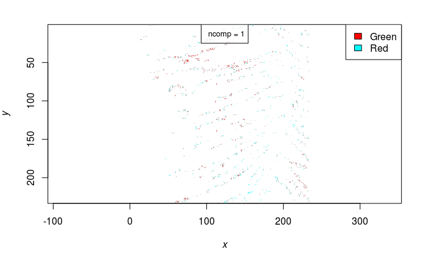

```r
image(moxsox.opls, model=list(ncomp=comp))
```

```r
scores<-moxsox.opls@resultData$`ncomp = 1`
opls.scores<-data.frame(t0=scores$Oscores, t1=scores$scores, Class=scores$classes)
ggplot(opls.scores, aes(x=C1, y=t0.C1, color=Class)) + geom_point() + xlab('t[1]') + ylab('t[0]')
```

```
Error in eval(expr, envir, enclos) : object 't0.C1' not found
```

Also not a preditive model – no t-orthoganol scores

One other possibility that would be good to consider is that the spatial variation may alter the structure of the dataset

## Split Dataset by spatial coordinates

Image compelete maldifishmz dataset

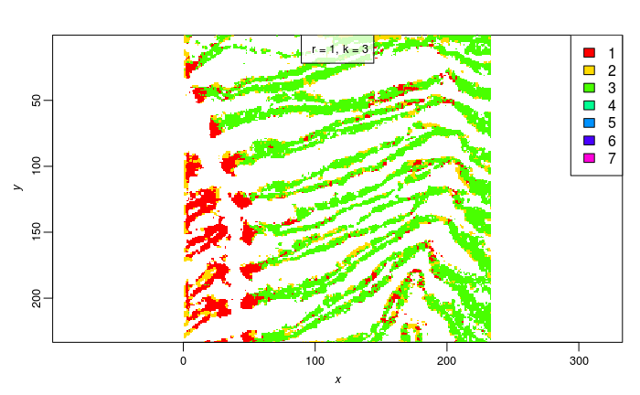

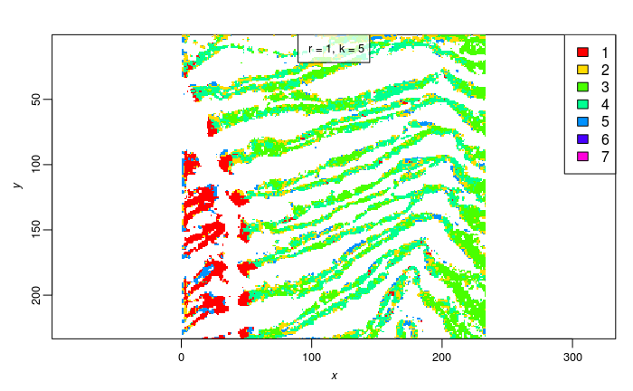

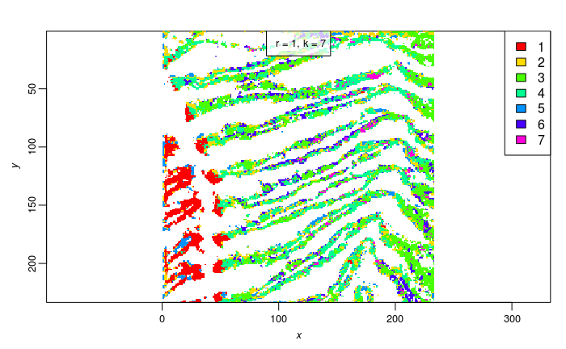

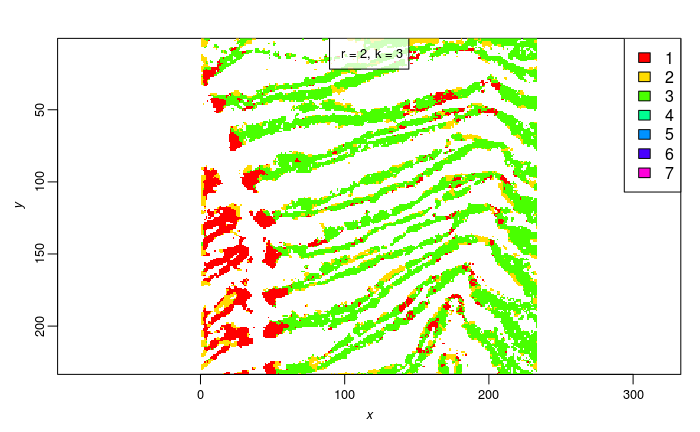

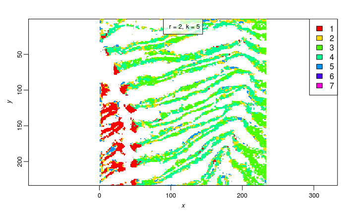

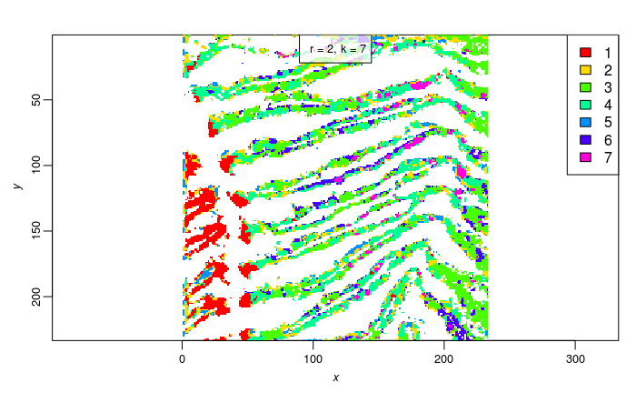

Take region between x=100 and 200

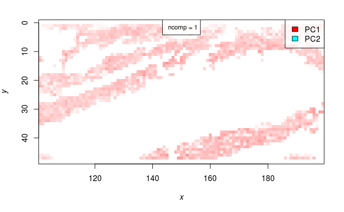

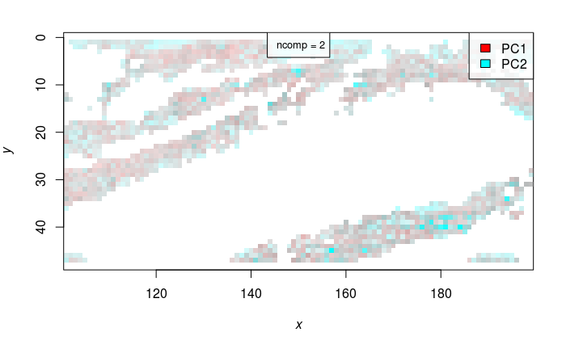

#### Run discriminate analysis bewteen host and mox signals

```r
hostmox<-msi[,msi$Class %in% c('Red','Tissue')]
table(hostmox$Class)
```

```
   Red Tissue
  1639   6728
```

```r
ddd<-data.frame(pData(hostmox))
ddd$xy<-paste(ddd$x, ddd$y,sep='-')
subset<-data.frame((pData(hostmox) %>% group_by(Class) %>% sample_n(size=400,replace = F)))
subset$xy<-paste(subset$x, subset$y,sep='-')
dnew<-ddd[ddd$xy %in% subset$xy,]
coordsSubset<-rownames(dnew)
hostmox.subset<-hostmox[,rownames(pData(hostmox)) %in% coordsSubset]
table(hostmox.subset$Class)
```

```
   Red Tissue
   400    400
```

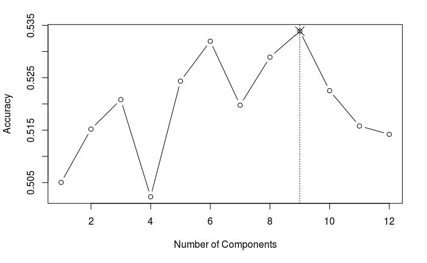

```r
hostmox.cv<-cvApply(hostmox.subset, .y = as.factor(hostmox.subset$Class), .fun = "OPLS", ncomp = 1:12, keep.Xnew = FALSE, .fold=CV)
plot(summary(hostmox.cv))
```

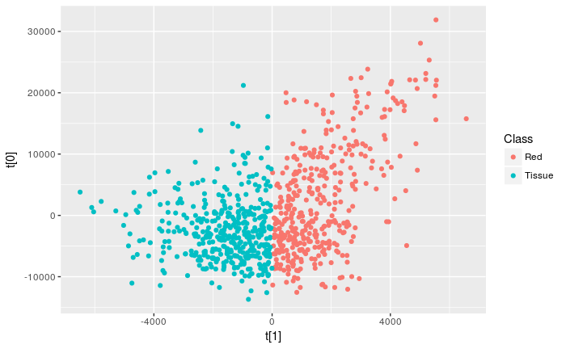

#### host vs sox

```r
hostsox<-msi[,msi$Class %in% c('Green','Tissue')]
table(hostsox$Class)
```

```
 Green Tissue
   410   6728
```

```r
ddd<-data.frame(pData(hostsox))
ddd$xy<-paste(ddd$x, ddd$y,sep='-')
subset<-data.frame((pData(hostsox) %>% group_by(Class) %>% sample_n(size=400,replace = F)))
subset$xy<-paste(subset$x, subset$y,sep='-')
dnew<-ddd[ddd$xy %in% subset$xy,]
coordsSubset<-rownames(dnew)
hostsox.subset<-hostsox[,rownames(pData(hostsox)) %in% coordsSubset]
table(hostsox.subset$Class)
```

```
 Green Tissue
   400    400
```

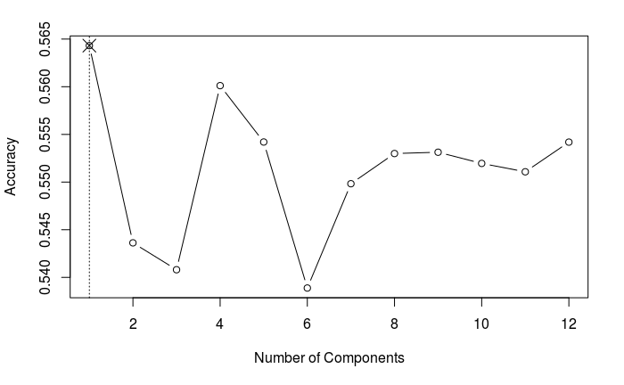

```r
hostsox.cv<-cvApply(hostsox.subset, .y = as.factor(hostsox.subset$Class), .fun = "OPLS", ncomp = 1:12, keep.Xnew = FALSE, .fold=CV)
plot(summary(hostsox.cv))
```

```r
ggplot(opls.scores, aes(x=C1, y=t0.C1, color=Class)) + geom_point() + xlab('t[1]') + ylab('t[0]')
```

```
Error in eval(expr, envir, enclos) : object 't0.C1' not found
```

#### Sox vs. Mox

```r
moxsox<-msi[,msi$Class %in% c('Green','Red')]
table(moxsox$Class)
```

```
Green   Red
  410  1639
```

```r
ddd<-data.frame(pData(moxsox))
ddd$xy<-paste(ddd$x, ddd$y,sep='-')
subset<-data.frame((pData(moxsox) %>% group_by(Class) %>% sample_n(size=400,replace = F)))
subset$xy<-paste(subset$x, subset$y,sep='-')
dnew<-ddd[ddd$xy %in% subset$xy,]
coordsSubset<-rownames(dnew)
moxsox.subset<-moxsox[,rownames(pData(moxsox)) %in% coordsSubset]
table(moxsox.subset$Class)
```

```
Green   Red
  400   400
```

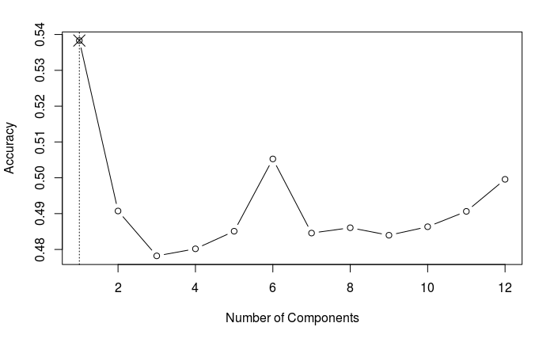

```r
moxsox.cv<-cvApply(moxsox.subset, .y = as.factor(moxsox.subset$Class), .fun = "OPLS", ncomp = 1:12, keep.Xnew = FALSE, .fold=CV)
plot(summary(moxsox.cv))
```

```r
scores<-opls@resultData$`ncomp = 1`
opls.scores<-data.frame(t0=scores$Oscores, t1=scores$scores, Class=scores$classes)
ggplot(opls.scores, aes(x=C1, y=t0.C1, color=Class)) + geom_point() + xlab('t[1]') + ylab('t[0]')
```

```
Error in eval(expr, envir, enclos) : object 't0.C1' not found
```

# Ion Distrubtion Plots

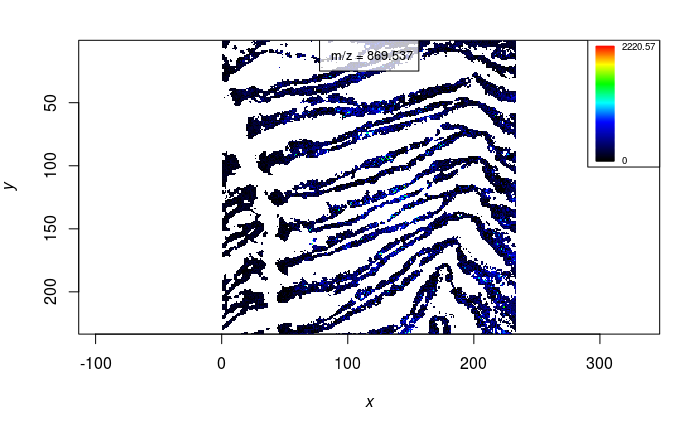